# Analisis de la Zona de Salamanca

Estudio de sobre los datos extraidos de idealista de la zona de Salamanca a traves del API de idealista.

| Total | Particulares | Agencias | Agencias.Exclusiva | Agencas.sin.Exclusiva |
| --- | --- | --- | --- | --- |
| 774 | 120 | 654 | 71 | 583 |

En el presente estudio, se han obtenido un total de **774** inmuebles. De este número, **120** corresponden a particulares y **654**. Utilizando como indicador el numero de agencias que publican la direccion completa en idealista, podemos realizar una estimación de publicaciones en exclusiva es **71**.

En la siguiente tabla se muestran los valores de mediana y desviacion Tipica para los diferentes tipos de inmuebles.

| Tipo | Cantidad | Media | Mediana metro 2 | Desviacion |
| --- | --- | --- | --- | --- |
| ático | 61 | 5034 | 4846 | 1116 |
| dúplex | 10 | 5435 | 4946 | 1526 |
| estudio | 27 | 3592 | 3611 | 1049 |
| piso | 676 | 3973 | 3784 | 1219 |

La siguiente grafica muestra el porcentaje de particulares frente al número de agencias en la zona.

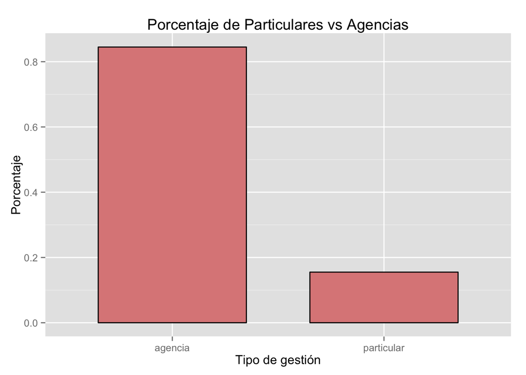

[figure not shown]

En el siguiente gráfico podemos ver una distribucion del precio por metro cuadrado en el total de los inmuebles de la zona.

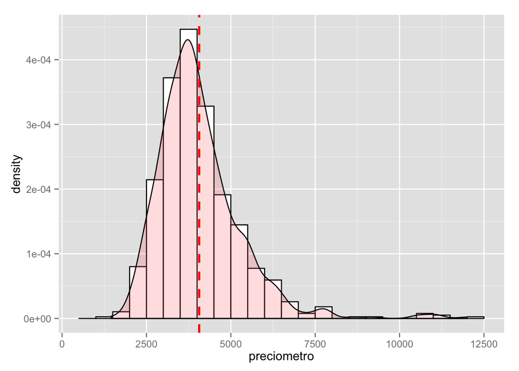

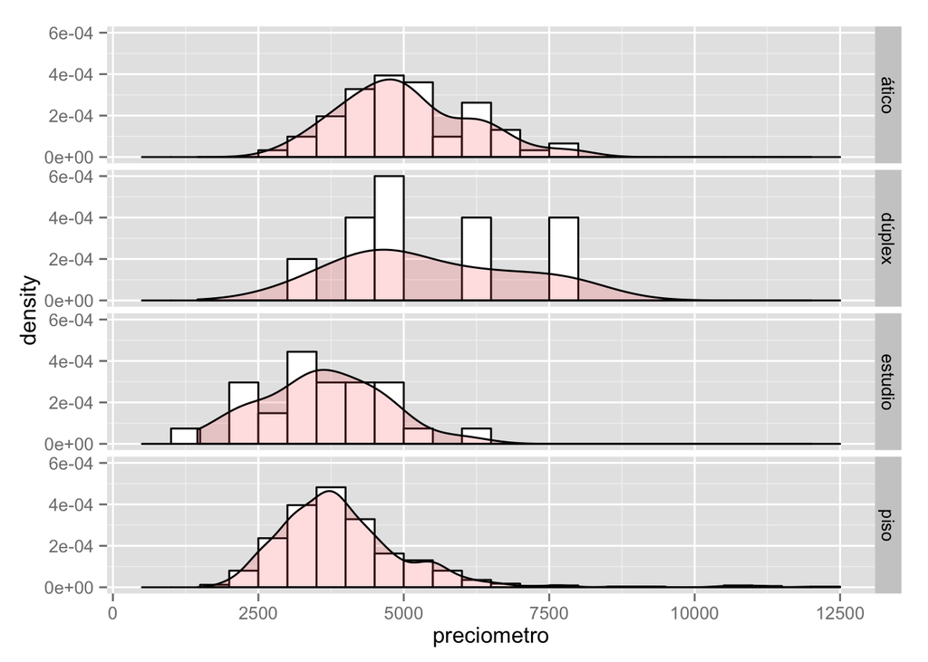

[output not shown]